# Week 15 - Intro to Modeling

Keanu Rochette

2024-12-06

```r
library(here)
library(tidyverse)
library(palmerpenguins)
library(performance)
library(modelsummary)
library(tidymodels)
library(broom)
#library(flextable)
#library(see)
```

## Anatomy of a model (simple)

```
mod <- lm(y~x, data = df)

mod: name of the model
y~x: y as a function x
```

Multiple regressions

```
mod <- lm(y~x1 + x2, data = df)
```

Interaction term

```
mod <- lm(y~x1*x2, data = df)

* is computed as x1+x2+x1:x2 (x1 interacting with x2)
x1:x2 : interaction of x1 and x2
```

## Example

```r
peng_mod <- lm(bill_length_mm ~ bill_depth_mm*species, data = penguins)
```

### Checking the model assumption with performance

In lm, we assume that the data are meets - assumption of normality, i.e. residuals of the models are normal - homogeneity of variance, - co-linearity….

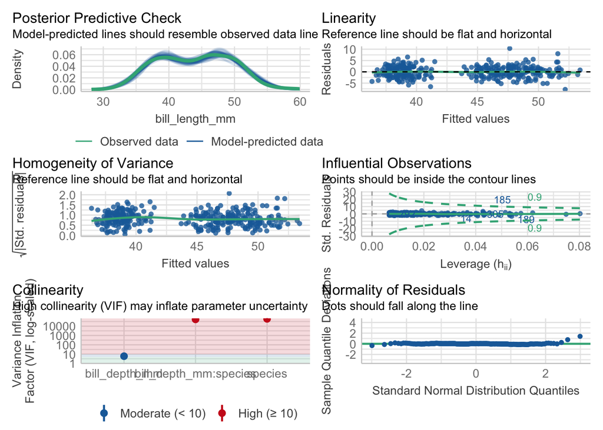

```r
check_model(peng_mod)
```

### ANOVA table

- significant rel betwn bill length and bill depth
- significant difference btwn species
- rel btwn bill depth and bill length change by spp

```r
anova(peng_mod)
```

```
## Analysis of Variance Table
##
## Response: bill_length_mm
##                        Df Sum Sq Mean Sq F value    Pr(>F)
## bill_depth_mm           1  561.6   561.6  93.965 < 2.2e-16 ***
## species                 2 7460.3  3730.2 624.151 < 2.2e-16 ***
## bill_depth_mm:species   2  134.3    67.1  11.232 1.898e-05 ***
## Residuals             336 2008.1     6.0
## ---
## Signif. codes:  0 '***' 0.001 '**' 0.01 '*' 0.05 '.' 0.1 ' ' 1
```

### Coefficients (effect size) with error

gives: - coefficients - intercepts - std error - p-values

```r
summary(peng_mod)
```

```
##
## Call:
## lm(formula = bill_length_mm ~ bill_depth_mm * species, data = penguins)
##
## Residuals:
##     Min      1Q  Median      3Q     Max
## -7.7888 -1.5415  0.0575  1.5873 10.3590
##
## Coefficients:
##                                Estimate Std. Error t value Pr(>|t|)
## (Intercept)                     23.0681     3.0165   7.647 2.18e-13 ***
## bill_depth_mm                    0.8570     0.1641   5.224 3.08e-07 ***
## speciesChinstrap                -9.6402     5.7154  -1.687 0.092590 .
## speciesGentoo                   -5.8386     4.5353  -1.287 0.198850
## bill_depth_mm:speciesChinstrap   1.0651     0.3100   3.435 0.000666 ***
## bill_depth_mm:speciesGentoo      1.1637     0.2789   4.172 3.84e-05 ***
## ---
## Signif. codes:  0 '***' 0.001 '**' 0.01 '*' 0.05 '.' 0.1 ' ' 1
##
## Residual standard error: 2.445 on 336 degrees of freedom
##   (2 observations deleted due to missingness)
## Multiple R-squared:  0.8024, Adjusted R-squared:  0.7995
## F-statistic: 272.9 on 5 and 336 DF,  p-value: < 2.2e-16
```

## Broom: view results cleanly

Puts the results of the ANOVA and the coeff in a clean tibble for export into Excel/CSV or plotting

```r
coeffs <- tidy(peng_mod) #tidy() gives the ANOVA results
coeffs
```

```
## # A tibble: 6 × 5
##   term                           estimate std.error statistic  p.value
##   <chr>                             <dbl>     <dbl>     <dbl>    <dbl>
## 1 (Intercept)                      23.1       3.02       7.65 2.18e-13
## 2 bill_depth_mm                     0.857     0.164      5.22 3.08e- 7
## 3 speciesChinstrap                 -9.64      5.72      -1.69 9.26e- 2
## 4 speciesGentoo                    -5.84      4.54      -1.29 1.99e- 1
## 5 bill_depth_mm:speciesChinstrap    1.07      0.310      3.44 6.66e- 4
## 6 bill_depth_mm:speciesGentoo       1.16      0.279      4.17 3.84e- 5
```

### Glance() : R-squared, AICs… etc.

- r-squared
- adj. r-squared
- p-values…etc

```r
results <- glance(peng_mod)
results
```

```
## # A tibble: 1 × 12
##   r.squared adj.r.squared sigma statistic   p.value    df logLik   AIC   BIC
##       <dbl>         <dbl> <dbl>     <dbl>     <dbl> <dbl>  <dbl> <dbl> <dbl>
## 1     0.802         0.799  2.44      273. 5.69e-116     5  -788. 1590. 1617.
## # ℹ 3 more variables: deviance <dbl>, df.residual <int>, nobs <int>
```

### Residuals

Used for fitted values/fitted predictions, useful for plotting, std error and more

```r
resid_fitted <- augment(peng_mod)
resid_fitted
```

```
## # A tibble: 342 × 10
##    .rownames bill_length_mm bill_depth_mm species .fitted   .resid    .hat
##    <chr>              <dbl>         <dbl> <fct>     <dbl>    <dbl>   <dbl>
##  1 1                   39.1          18.7 Adelie     39.1  0.00553 0.00719
##  2 2                   39.5          17.4 Adelie     38.0  1.52    0.0107
##  3 3                   40.3          18   Adelie     38.5  1.81    0.00716
##  4 5                   36.7          19.3 Adelie     39.6 -2.91    0.0107
##  5 6                   39.3          20.6 Adelie     40.7 -1.42    0.0295
##  6 7                   38.9          17.8 Adelie     38.3  0.577   0.00797
##  7 8                   39.2          19.6 Adelie     39.9 -0.666   0.0137
##  8 9                   34.1          18.1 Adelie     38.6 -4.48    0.00690
##  9 10                  42            20.2 Adelie     40.4  1.62    0.0221
## 10 11                  37.8          17.1 Adelie     37.7  0.0768  0.0136
## # ℹ 332 more rows
## # ℹ 3 more variables: .sigma <dbl>, .cooksd <dbl>, .std.resid <dbl>
```

## Results un {modelsummary}

2 families of functions: - modelsummary - modelsummary: Regression tables with side-by-side models. - modelsummary_wide: Regression tables for categorical response models or grouped coefficients. - modelplot: Coefficient plots. - datasummary - datasummary: Powerful tool to create (multi-level) cross-tabs and data summaries. - datasummary_balance: Balance tables with subgroup statistics and difference in means (aka “Table 1”). - datasummary_correlation: Correlation tables. - datasummary_skim: Quick overview (“skim”) of a dataset. - datasummary_df: Turn dataframes into nice tables with titles, notes, etc.

### Example

Looking at a penguin model with no interactions

```r
# New model
peng_mod_noX<-lm(bill_length_mm ~ bill_depth_mm, data = penguins)
#Make a list of models and name them
models<-list("Model with interaction" = peng_mod,
             "Model with no interaction" = peng_mod_noX)
#Save the results as a .docx
modelsummary(models, output = here("Week_15","outputs","table.docx"))
```